# Homework 3

# Submission Instructions

- Please submit your responses as a nicely formatted notebook (.ipynb) file.
- For questions that require calculations:
  - Show your work (i.e., show the R code you used to answer the question).
  - Make sure all the code you used to answer the question has been run (i.e., displays an output) otherwise you will get a zero for that question.
  - If your *answer* includes many decimal places (e.g., 3.14159265358979), please round it to a reasonable number of decimals for readability (typically 3 to 5).
  - There should be no rounding inside the calculations you do, only round the final result if necessary.
  - For ease of marking, avoid showing the outputs of unnecessary values.
  - Unless specified otherwise, assume $\alpha = 0.05$.
  - Only apply trimming when explicitly instructed to do so.

# Question 1

### Use the R functions `qnorm()`, `pnorm()`, `qt()`, and `pt()` to answer questions a - m. Round values to 5 decimals.

## a.

What z-score represents the 50th percentile?

```r
round(qnorm(0.5, mean = 0, sd = 1), 5)
```

```
## [1] 0
```

## b.

What t-score indicates the 50th percentile for a t-distribution with a degrees of freedom of 13?

```r
round(qt(0.5, df = 13), 5)
```

```
## [1] 0
```

## c.

What t-score represents the 75th percentile for a t-distribution with 13 degrees of freedom?

```r
round(qt(0.75, df = 13), 5)
```

```
## [1] 0.69383
```

## d.

What z-scores represents the middle 95% of a normal distribution?

```r
# Lower Bound
round(qnorm(0.025, mean = 0, sd = 1), 5)
```

```
## [1] -1.95996
```

```r
# Upper Bound
round(qnorm(0.025, mean = 0, sd = 1, lower.tail = FALSE), 5)
```

```
## [1] 1.95996
```

## e.

What t-scores represents the middle 99% of a t-distribution with 22 degrees of freedom?

```r
# Lower Bound
round(qt(0.005, df = 22), 5)
```

```
## [1] -2.81876
```

```r
# Upper Bound
round(qt(0.005, df = 22, lower.tail = FALSE), 5)
```

```
## [1] 2.81876
```

## f.

What t-score represents the 2.5th percentile of a t-distribution with 22 degrees of freedom?

```r
round(qt(0.025, df = 22), 5)
```

```
## [1] -2.07387
```

## g.

What z-score represents the top 2.5% of a normal distribution?

```r
round(qnorm(0.025, mean = 0, sd = 1, lower.tail = FALSE), 5)
```

```
## [1] 1.95996
```

## h.

What t-score represents the top 2.5% of a t-distribution with 1000 degrees of freedom?

```r
round(qt(0.025, df = 1000, lower.tail = FALSE), 5)
```

```
## [1] 1.96234
```

## i.

What percentile does a t-score of -1.9 represent, for a t-distribution with 13 degrees of freedom?

```r
round(pt(-1.9, df = 13) * 100, 5)
```

```
## [1] 3.99207
```

## j.

What percentile does the value 120 represent, for a normal distribution with a mean of 100 and a standard devaition of 15?

```r
round(pnorm(120, mean = 100, sd = 15) * 100, 5)
```

```
## [1] 90.87888
```

## k.

What is the 17th percentile, for a normal distribution with a mean of 100 and a standard devaition of 15?

```r
round(qnorm(0.17, mean = 100, sd = 15), 5)
```

```
## [1] 85.68752
```

## l.

What is the 17th percentile, for a normal distribution with a mean of 0 and a standard devaition of 1?

```r
round(qnorm(0.17, mean = 0, sd = 1), 5)
```

```
## [1] -0.95417
```

## m.

What is the 17th percentile, for a t-distribution with 1000 degrees of freedom?

```r
round(qt(0.17, df = 1000), 5)
```

```
## [1] -0.95462
```

# Question 2

### Use the following *sampled* data to answer questions a - h:

-54, -126, -92, -109, -113, -94, -110, -87, -83, -82, -85, -111, -74, -123, -89, -101, -97, -113, -77, -99, -90, -103, -116, -98, -81, -88, -97, -117, -95, -104, -111, -84, -125, -59, -97

## a.

Determine if it is reasonable to assume that the population is normally distributed based on the sample data.

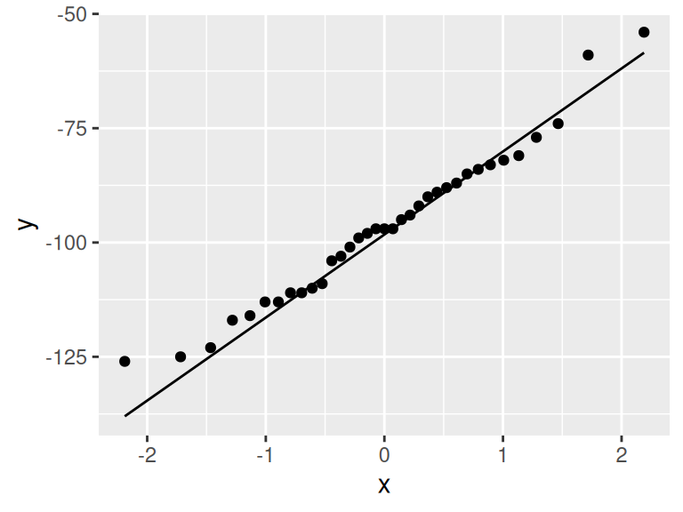

```r
library(tidyverse)

x <- c(
  -54, -126, -92, -109, -113, -94, -110, -87, -83, -82,
  -85, -111, -74, -123, -89, -101, -97, -113, -77, -99,
  -90, -103, -116, -98, -81, -88, -97, -117, -95, -104,
  -111, -84, -125, -59, -97
)

ggplot(mapping = aes(sample = x)) +
  stat_qq() +
  stat_qq_line()
```

> The assumption of a normally distributed population seems reasonable.

*Note for grading: Evaluation of normality needs to include, at a minimum, a Q-Q plot.*

## b.

Without using the functions `mean()`, `var()`, or `sd()`, calculate the sample size, mean, standard deviation, and standard error of the mean.

```r
# Sample Size:
N <- length(x)
N
```

```
## [1] 35
```

```r
# Mean
m <- sum(x) / N
round(m, 4)
```

```
## [1] -96.6857
```

```r
# Standard Deviation
s <- sqrt(sum((x - m)^2) / (N - 1))
round(s, 4)
```

```
## [1] 17.0859
```

```r
# Standard Error
se <- s/sqrt(N)
round(se, 4)
```

```
## [1] 2.888
```

## c.

Find the **two** critical values that represent the middle 95% boundries on a t-distribution.

```r
alpha <- 0.05
df <- N - 1

# Lower Bound
t_crit_low <- qt(alpha/2, df = df)
round(t_crit_low, 4)
```

```
## [1] -2.0322
```

```r
# Upper Bound
t_crit_high <- qt(alpha/2, df = df, lower.tail = FALSE)
round(t_crit_high, 4)
```

```
## [1] 2.0322
```

## d.

If $H_0: \mu = -90$, calculate a 95% confidence interval to test this hypothesis. Do you reject the hypothesis (explain your reasoning in terms of the confidence interval)? You are not permitted to use the function `t.test()` to answer this question.

```r
lower <- m + t_crit_low * se
upper <- m + t_crit_high * se
```

```
## [-102.5549, -90.8165]
```

> Since $\mu = -90$ is found outside the interval $[ -102.555 , -90.817 ]$, we reject $H_0$.

## e.

If $\alpha = 0.05$, calculate a p-value to test $H_0: \mu = -90$. Do you reject the hypothesis? You are not permitted to use the function `t.test()`.

```r
# Test Statistic
mu <- -90
test_stat <- (m - mu) / se
round(test_stat, 4)
```

```
## [1] -2.315
```

```r
# p-value
# Note: since the test statistic is negative (i.e., the sample mean is less
# than mu) we need to calculate the probability from left to right.
p <- pt(test_stat, df = df) * 2
round(p, 4)
```

```
## [1] 0.0268
```

> Since $p = 0.027$ is less than $\alpha = 0.05$, we reject $H_0$.

## f.

Use the function `t.test()` to compute a confidence interval and a p-value for the previous question’s null hypothesis.

```r
t.test(x, mu = -90)
```

```
##
##  One Sample t-test
##
## data:  x
## t = -2.315, df = 34, p-value = 0.02678
## alternative hypothesis: true mean is not equal to -90
## 95 percent confidence interval:
##  -102.5549  -90.8165
## sample estimates:
## mean of x
## -96.68571
```

## g.

Repeat question e. testing $H_0: \mu > -90$. You are not permitted to use the function `t.test()`.

```r
# p-value:
# Note: To reject this hypothesis we need to find a value smaller than -90,
# which means the critical (rejection) region is in the left tail, and thus
# we calculate the p-value from left to right again.

p <- pt(test_stat, df = df)
round(p, 4)
```

```
## [1] 0.0134
```

> Since $p = 0.013$ is less than $\alpha = 0.05$, we reject $H_0$.

## h.

Use the function `t.test()` to test the hypothesis $H_0: \mu > -90$. $\alpha = 0.05$

```r
t.test(x, mu = mu, alternative = c("less"))
```

```
##
##  One Sample t-test
##
## data:  x
## t = -2.315, df = 34, p-value = 0.01339
## alternative hypothesis: true mean is less than -90
## 95 percent confidence interval:
##       -Inf -91.80225
## sample estimates:
## mean of x
## -96.68571
```

# Question 3

### If you get a sample mean of 45 based on 25 participants and the sample standard deviation is 5, what is the two-sided 95% confidence interval? Assume random sampling from a normally distributed population.

```r
N <- 25
m <- 45
s <- 5
df <- N - 1
se <- s/sqrt(N)

alpha <- 0.05
t_crit <- abs(qt(alpha/2, df = df))

lower <- m - t_crit * se
upper <- m + t_crit * se
```

```
## [42.9361, 47.0639]
```

# Question 4

### Repeat the previous question, except compute a two-sided 99% confidence interval.

```r
alpha <- 0.01
t_crit <- abs(qt(alpha/2, df = df))

lower <- m - t_crit * se
upper <- m + t_crit * se
```

```
## [42.2031, 47.7969]
```

# Question 5

### A manufacturer claims that its light bulbs have an average life span of $\mu = 1200$ hours. You randomly test 36 bulbs and find that the average life span is $\bar{x} = 1150$ with a standard deviation of 25. Does a 95% confidence interval suggest that the manufacter’s claim is unreasonable? Assume random sampling from a normally distributed population.

```r
N <- 36
m <- 1150
s <- 25
df <- N - 1
se <- s/sqrt(N)

alpha <- 0.05
t_crit <- abs(qt(alpha/2, df = df))

lower <- m - t_crit * se
upper <- m + t_crit * se
```

```
## [1] "[1141.5412, 1158.4588]"
```

> Yes the interval suggests the claim is unreasonable. The manufacturer’s value 1200 falls outside of the 95% confidence interval.

# Question 6

### If $N = 10$ observations are randomly sampled from a normal distribution with $\mu = 9$ and $\sigma = 8$, what is the mean and standard deviation of the *sampling distribution* of the mean?

```r
N <- 10
m <- 9
s <- 8
se <- s / sqrt(N) # Std. Err = Std. Dev. of a sampling distribution.
round(se, 4)
```

```
## [1] 2.5298
```

> The mean of the sampling distribution is 9 and the standard deviation of the sampling distribution (i.e., the standard error) is 2.53.

# Question 7

### What is the variance of the sampling distribution from the previous question?

```r
var <- s^2 / N
# or
var <- (s / sqrt(N))^2

round(var, 4)
```

```
## [1] 6.4
```

# Question 8

### Given that $\bar{x} = 78$, $s = 25$, $N = 10$, and $\alpha = 0.05$, test the hypothesis that $H_0: \mu > 80$. Assume observations are randomly sampled from a normal distribution.

Report:

- the test statistic
- degrees of freedom
- confidence interval
- p-value
- whether your reject or fail to reject the $H_0$

```r
mu <- 80
m <- 78
s <- 25
N <- 10
se <- s/sqrt(N)
df <- N - 1

# Confidence Interval
alpha <- 0.05
t_crit <- abs(qt(alpha, df = df))
low_ci <- -Inf
top_ci <- m + t_crit * se

# P-value
t <- (m - mu) / se
p <- pt(t, df = df)
```

```
## Test statistic: -0.253
```

```
## df = 9
```

```
## [-Inf, 92.492]
```

```
## p = 0.403
```

> Since 80 ($\mu_0$) is contained within the confidence interval, we fail to reject.

> … Or … since p > 0.05, we fail to reject.

# Question 9

### Repeat the previous question, but test $H_0: \mu = 80$.

```r
# Confidence Interval
t_crit <- abs(qt(alpha / 2, df = df))
low_ci <- m - t_crit * se
top_ci <- m + t_crit * se

# P-value
p <- pt(t, df = df) * 2
```

```
## Test statistic: -0.253
```

```
## df = 9
```

```
## 95% CI = [60.1161, 95.8839]
```

```
## p = 0.806
```

> Since 80 ($\mu_0$) is contained within the confidence interval, we fail to reject.

> … Or … since p > 0.05, we fail to reject.

# Question 10

### Assume you have the following data:

### 94, 94, 74, 103, 121, 77, 117, 89, 101, 97, 95, 119, 100, 145, 111, 88, 81, 103, 126, 97, 88, 83, 128, 77, 129

### If $H_0: \mu \geq 110$, compute a one-sided 95% confidence interval and evaluate whether you should reject $H_0$.

- Use of `t.test()` is not permitted to solve this question (though its probably a good idea to use it to check your result).

```r
x <- c(
  94, 94, 74, 103, 121, 77, 117, 89, 101,
  97, 95, 119, 100, 145, 111, 88, 81, 103,
  126, 97, 88, 83, 128, 77, 129
)

N <- length(x)
m <- mean(x)
se <- sd(x) / sqrt(N)
df <- N - 1

alpha <- 0.05
t_crit <- abs(qt(alpha, df = df))

# CI boundary
lower <- -Inf
upper <- m + t_crit * se
```

```
## [-Inf, 107.8854]
```

> Since $110$ is not contained within the interval we reject $H_0$.

# Question 11

### Using the previous question’s data, what is the 95% Confidence Interval if $H_0: \mu \leq 90$? Do you reject $H_0$?

```r
alpha <- 0.05
t_crit <- abs(qt(alpha, df = df))

# CI boundary
lower <- m - t_crit * se
upper <- Inf
```

```
## [95.0746, Inf]
```

> Since $90$ is not contained within the interval we reject $H_0$.

# Question 12

### What determines which side infinity ($\infty$) falls on in a one-sided confidence interval? Is it the significance of the test or the direction of the hypothesis?

> Direction of the hypothesis. Tip: the interval will always be expressed in terms of the alternative hypothesis.

# Question 13

### On the course website you will find a data set called **AllTimeMovies.csv**. It contains the top 79 all-time movies as of 2003 by domestic (US) gross receipts. Evaluate whether domestic (US) gross is normally distributed.

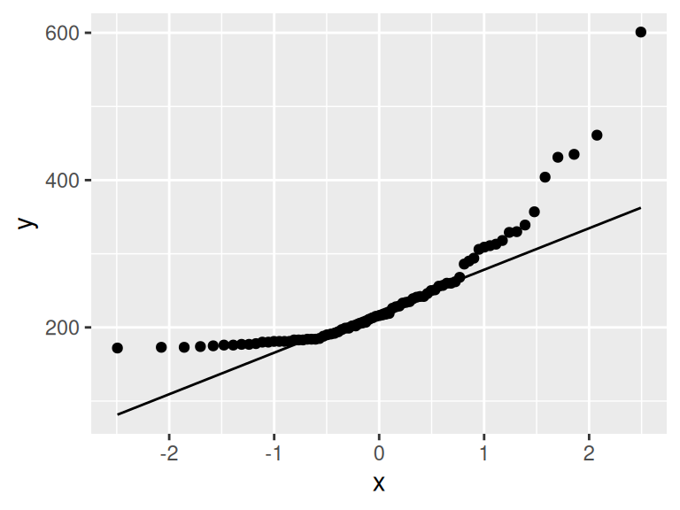

```r
movies <- read_csv("../Data/AllTimeMovies.csv")

ggplot(movies, aes(sample = Gross)) +
  stat_qq() +
  stat_qq_line()
```

> The points show a systematic departure from a straight line, meaning it is not reasonable to assume this data is normally distributed.

*Note for grading: Evaluation of normality needs to include, at a minimum, a Q-Q plot.*

# Question 14

### Using the data set **AllTimeMovies.csv**, calculate a two-sided 95% confidence interval on the trimmed mean for the movies’ domestic (US) gross. Use 20% trimming.

```r
library(WRS2)

# Sample Size
N <- length(movies$Gross)

# Amount of Trimming
G <- 0.2

# Trimmed mean
m <- mean(movies$Gross, tr = G)

# Winsorized Variance and Standard Deviation
var <- winvar(movies$Gross, tr = G)
s <- sqrt(var)

# Standard Error of Trimmed Mean
se <- s / ((1-2*G) * sqrt(N))

# Degrees of Freedom
h <- N - 2 * floor(G * N)
df <- h - 1

# Critical T
alpha <- 0.05
t_crit <- abs(qt(alpha/2, df = df))

lower <- m - t_crit * se
upper <- m + t_crit * se
```

```
## [204.3407, 235.7817]
```

# Question 15

### Using the movie data from the previous question, test $H_0: \mu = 240.19$ using $20\%$ trimmed means.

Report:

- the test statistic
- degrees of freedom
- p-value
- whether your reject or fail to reject the $H_0$

```r
mu <- 240.19
t <- (m - mu) / se

p <- pt(t, df = df) * 2
```

```
## Test statistic: -2.5744
```

```
## df = 48
```

```
## p = 0.0132
```

```
## Since p < .05 we reject the null hypothesis.
```

# Question 16

### A company claims that on average, when exposed to its toothpaste, 45% of all bacteria related to gingivitis is killed. You run 10 tests and find that the percentages of bacteria killed among these tests are

### 38, 44, 62, 72, 43, 40, 43, 42, 39, 41

### Assuming the data comes from a normally distributed population, test the hypothesis that the average percentage is 45 with $\alpha = 0.01$ (not $\alpha = 0.05$). Calculate both a p-value and a confidence interval. Assume observations are randomly sampled from a normal distribution. Use of `t.test()` is not permitted.

Make sure to report:

- the test statistic
- degrees of freedom
- Confidence interval
- p-value
- whether your reject or fail to reject the $H_0$

```r
data <- c(38,44,62,72,43,40,43,42,39,41)
mu <- 45

m <- mean(data)
s <- sd(data)
N <- length(data)
se <- s/sqrt(N)

# Degrees of Freedom
df <- N - 1

# Critical T-value
# (note: .01 needs to be divided by 2 because it is a two tailed test)
alpha <- 0.01
t_crit <- abs(qt(alpha / 2, df = df))

# Test statistic
t <- (m - mu)/se

# P-value
p <- pt(t, df = df, lower.tail = FALSE) * 2

# 99% Confidence Interval
CI_bottom <- m - t_crit * se
CI_top <- m + t_crit * se
```

```
## Test statistic: 0.393
```

```
## df = 9
```

```
## 99% CI = [34.8216, 57.9784]
```

```
## p = : 0.7035
```

```
## Since p > .05 we fail to reject
```

# Question 17

### Use the R function `t.test()` to calculate the previous question’s answer.

- Hint, R’s help documentation is useful here.

```r
t.test(data, mu = 45, alternative = c("two.sided"), conf.level = .99)
```

```
##
##  One Sample t-test
##
## data:  data
## t = 0.39295, df = 9, p-value = 0.7035
## alternative hypothesis: true mean is not equal to 45
## 99 percent confidence interval:
##  34.82158 57.97842
## sample estimates:
## mean of x
##      46.4
```

# Question 18

### Recalculate the confidence interval and p-value for the previous question with the hypothesis $H_0: \mu > 45$. Do not use `t.test()`.

```r
# Confidence Interval
t_crit <- abs(qt(alpha, df = df))
CI_bottom <- -Inf
CI_top <- m + t_crit * se

paste("99% CI = ", "[", round(CI_bottom, 4), ", ", round(CI_top, 4), "]",
      sep = '')
```

```
## [1] "99% CI = [-Inf, 56.4521]"
```

```r
#P-value
p <- pt(t, df = df)
round(p, 4)
```

```
## [1] 0.6483
```

*Note for grading: use of `paste()` to display the interval is not necessary.*